# R Project1

```r
#install.packages("tidyverse")
female <- read.csv("female.csv")
is.data.frame(female)
```

```
## [1] TRUE
```

```r
head(female)
```

|  | Series.Name | Series.Code | Country.Name | Country.Code | X1990..YR1990. | X2000..YR2000. | X2013..YR2013. | X2014..YR2014. | X2015..YR2015. | X2016..YR2016. | X2017..YR2017. | X2018..YR2018. | X2019..YR2019. | X2020..YR2020. | X2021..YR2021. | X2022..YR2022. |
| --- | --- | --- | --- | --- | --- | --- | --- | --- | --- | --- | --- | --- | --- | --- | --- | --- |
| 1 | Account ownership at a financial institution or with a mobile-money-service provider, female (% of population ages 15+) | FX.OWN.TOTL.FE.ZS | Afghanistan | AFG | .. | .. | .. | 3.81 | .. | .. | 7.16 | .. | .. | .. | 4.7 | .. |
| 2 | Account ownership at a financial institution or with a mobile-money-service provider, female (% of population ages 15+) | FX.OWN.TOTL.FE.ZS | Albania | ALB | .. | .. | .. | 33.59 | .. | .. | 38.1 | .. | .. | .. | 45.69 | .. |
| 3 | Account ownership at a financial institution or with a mobile-money-service provider, female (% of population ages 15+) | FX.OWN.TOTL.FE.ZS | Algeria | DZA | .. | .. | .. | 40.07 | .. | .. | 29.27 | .. | .. | .. | 31.19 | .. |
| 4 | Account ownership at a financial institution or with a mobile-money-service provider, female (% of population ages 15+) | FX.OWN.TOTL.FE.ZS | American Samoa | ASM | .. | .. | .. | .. | .. | .. | .. | .. | .. | .. | .. | .. |
| 5 | Account ownership at a financial institution or with a mobile-money-service provider, female (% of population ages 15+) | FX.OWN.TOTL.FE.ZS | Andorra | AND | .. | .. | .. | .. | .. | .. | .. | .. | .. | .. | .. | .. |
| 6 | Account ownership at a financial institution or with a mobile-money-service provider, female (% of population ages 15+) | FX.OWN.TOTL.FE.ZS | Angola | AGO | .. | .. | .. | 22.33 | .. | .. | .. | .. | .. | .. | .. | .. |

```r
library(tidyverse)
female <- female %>%
  filter(Country.Name == "Brazil" | Country.Name == "India" | Country.Name == "United States")

head(female)
```

|  | Series.Name | Series.Code | Country.Name | Country.Code | X1990..YR1990. | X2000..YR2000. | X2013..YR2013. | X2014..YR2014. | X2015..YR2015. | X2016..YR2016. | X2017..YR2017. | X2018..YR2018. | X2019..YR2019. | X2020..YR2020. | X2021..YR2021. | X2022..YR2022. |
| --- | --- | --- | --- | --- | --- | --- | --- | --- | --- | --- | --- | --- | --- | --- | --- | --- |
| 1 | Account ownership at a financial institution or with a mobile-money-service provider, female (% of population ages 15+) | FX.OWN.TOTL.FE.ZS | Brazil | BRA | .. | .. | .. | 64.77 | .. | .. | 67.51 | .. | .. | .. | 80.87 | .. |
| 2 | Account ownership at a financial institution or with a mobile-money-service provider, female (% of population ages 15+) | FX.OWN.TOTL.FE.ZS | India | IND | .. | .. | .. | 43.13 | .. | .. | 76.64 | .. | .. | .. | 77.55 | .. |
| 3 | Account ownership at a financial institution or with a mobile-money-service provider, female (% of population ages 15+) | FX.OWN.TOTL.FE.ZS | United States | USA | .. | .. | .. | 94.8 | .. | .. | 92.69 | .. | .. | .. | 96.79 | .. |

```r
colnames(female)
```

```
##  [1] "Series.Name"    "Series.Code"    "Country.Name"   "Country.Code"
##  [5] "X1990..YR1990." "X2000..YR2000." "X2013..YR2013." "X2014..YR2014."
##  [9] "X2015..YR2015." "X2016..YR2016." "X2017..YR2017." "X2018..YR2018."
## [13] "X2019..YR2019." "X2020..YR2020." "X2021..YR2021." "X2022..YR2022."
```

```r
rel_col <- which(colnames(female)=="Country.Name" | colnames(female)== "X2014..YR2014." | colnames(female)== "X2017..YR2017." | colnames(female) == "X2021..YR2021." )
rel_col
```

```
## [1]  3  8 11 15
```

```r
female <- female[rel_col] %>% rename("2014" = 2, "2017" = 3, "2021" = 4)
head(female)
```

|  | Country.Name | 2014 | 2017 | 2021 |
| --- | --- | --- | --- | --- |
| 1 | Brazil | 64.77 | 67.51 | 80.87 |
| 2 | India | 43.13 | 76.64 | 77.55 |
| 3 | United States | 94.8 | 92.69 | 96.79 |

```r
transpose_f <- data.frame(t(female[-1]))
colnames(transpose_f) <- female[, 1]
head(transpose_f)
```

|  | Brazil | India | United States |
| --- | --- | --- | --- |
| 2014 | 64.77 | 43.13 | 94.8 |
| 2017 | 67.51 | 76.64 | 92.69 |
| 2021 | 80.87 | 77.55 | 96.79 |

```r
print(sapply(transpose_f, class))
```

```
##        Brazil         India United States
##   "character"   "character"   "character"
```

```r
transpose_f$Brazil = as.numeric(transpose_f$Brazil)
transpose_f$India = as.numeric(transpose_f$India)
transpose_f$"United States" = as.numeric(transpose_f$"United States")
head(transpose_f)
```

|  | Brazil | India | United States |
| --- | --- | --- | --- |
| 2014 | 64.77 | 43.13 | 94.80 |
| 2017 | 67.51 | 76.64 | 92.69 |
| 2021 | 80.87 | 77.55 | 96.79 |

```r
transpose_f <- transpose_f %>% mutate_if(is.numeric, as.character)
head(transpose_f)
```

|  | Brazil | India | United States |
| --- | --- | --- | --- |
| 2014 | 64.77 | 43.13 | 94.8 |
| 2017 | 67.51 | 76.64 | 92.69 |
| 2021 | 80.87 | 77.55 | 96.79 |

```r
transpose_f <- transpose_f %>% mutate_if(is.character, as.numeric)
head(transpose_f)
```

|  | Brazil | India | United States |
| --- | --- | --- | --- |
| 2014 | 64.77 | 43.13 | 94.80 |
| 2017 | 67.51 | 76.64 | 92.69 |
| 2021 | 80.87 | 77.55 | 96.79 |

```r
summarise_each(transpose_f, list(mean))
```

| Brazil | India | United States |
| --- | --- | --- |
| 71.05 | 65.77333 | 94.76 |

```r
transpose_f %>%
  summarise(across(c(Brazil, India, "United States"), list(mean=mean, sd=sd)))
```

| Brazil_mean | Brazil_sd | India_mean | India_sd | United States_mean | United States_sd |
| --- | --- | --- | --- | --- | --- |
| 71.05 | 8.614012 | 65.77333 | 19.61498 | 94.76 | 2.050293 |

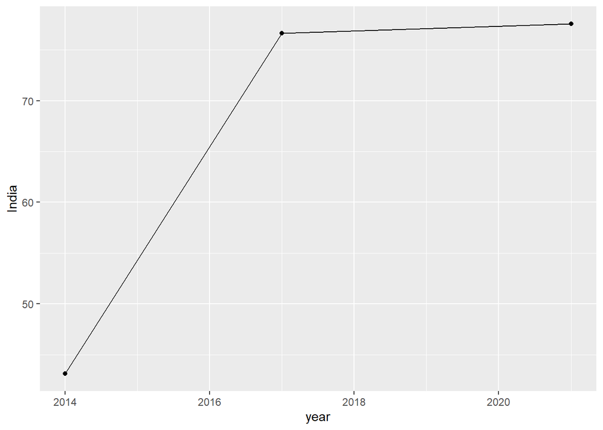

```r
year <- c(2014, 2017,2021)
ggplot(data=transpose_f, aes(x=year, y=India, group=1)) +
  geom_line()+
  geom_point()
```

```r
male <- read.csv(file = "male.csv")
male <- male %>%
  filter(Country.Name == "Brazil" | Country.Name == "India" | Country.Name == "United States")

male <- male[rel_col] %>%
  rename("2014" = 2, "2017" = 3, "2021" = 4)

transpose_m <- data.frame(t(male[-1]))
colnames(transpose_m) <- male[, 1]

transpose_m$Brazil = as.numeric(as.character(transpose_m$Brazil))
transpose_m$India = as.numeric(as.character(transpose_m$India))
transpose_m$"United States" = as.numeric(as.character((transpose_m$"United States")))

head(transpose_m)
```

|  | Brazil | India | United States |
| --- | --- | --- | --- |
| 2014 | 71.69 | 62.76 | 92.36 |
| 2017 | 72.85 | 83.01 | 93.57 |
| 2021 | 87.05 | 77.51 | 93.09 |

```r
transpose_m <- rename(transpose_m, "Brazil_m" = 1, "India_m" = 2, "United_States_m" = 3)

head(transpose_m)
```

|  | Brazil_m | India_m | United_States_m |
| --- | --- | --- | --- |
| 2014 | 71.69 | 62.76 | 92.36 |
| 2017 | 72.85 | 83.01 | 93.57 |
| 2021 | 87.05 | 77.51 | 93.09 |

```r
transpose_m <- rownames_to_column(transpose_m, var="Year")
transpose_f <- rownames_to_column(transpose_f, var="Year")
acct_owner_by_gender <- merge(x = transpose_m, y = transpose_f, by = "Year", all.x = TRUE)
acct_owner_by_gender <- rename(acct_owner_by_gender, "United_States" = 7)
head(acct_owner_by_gender)
```

|  | Year | Brazil_m | India_m | United_States_m | Brazil | India | United_States |
| --- | --- | --- | --- | --- | --- | --- | --- |
| 1 | 2014 | 71.69 | 62.76 | 92.36 | 64.77 | 43.13 | 94.80 |
| 2 | 2017 | 72.85 | 83.01 | 93.57 | 67.51 | 76.64 | 92.69 |
| 3 | 2021 | 87.05 | 77.51 | 93.09 | 80.87 | 77.55 | 96.79 |

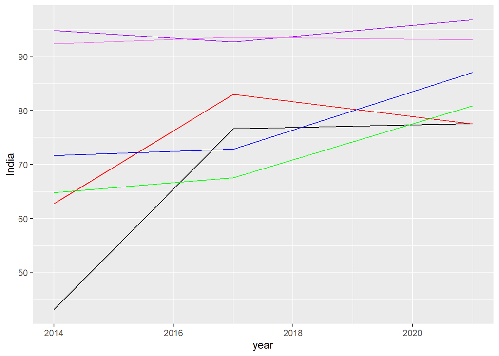

```r
gfg_plot <- ggplot(acct_owner_by_gender, aes(x=year )) +
    geom_line(aes(y = India), color = "black") +
    geom_line(aes(y = India_m), color = "red") +
    geom_line(aes(y = Brazil), color = "green") +
    geom_line(aes(y = Brazil_m), color = "blue") +
    geom_line(aes(y = United_States), color = "purple") +
    geom_line(aes(y = United_States_m), color = "violet")

gfg_plot
```

**Project 1**

1.(Cleaning up the final plot) The final plot is somewhat misleading: the y-axis is titled “India”. Write down the code that will change it to percentage ownership.

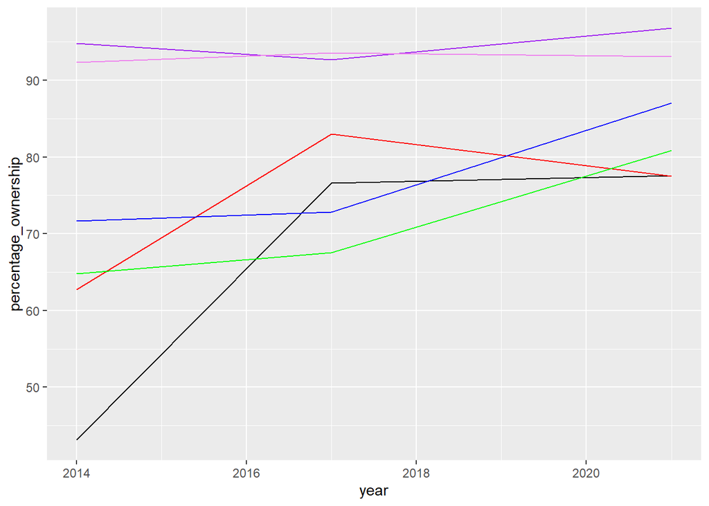

```r
gfg_plot <- ggplot(acct_owner_by_gender, aes(x=year , y=percentage_ownership), ) +
    geom_line(aes(y = India), color = "black") +
    geom_line(aes(y = India_m), color = "red") +
    geom_line(aes(y = Brazil), color = "green") +
    geom_line(aes(y = Brazil_m), color = "blue") +
    geom_line(aes(y = United_States), color = "purple") +
    geom_line(aes(y = United_States_m), color = "violet")
gfg_plot
```

2.(Drawing Conclusions) After drawing the plot that includes how percentages change over time, use this to draw some (fairly basic) conclusions on the how the ownership percentages have been changed. For example, you can discuss whether males have more account ownership than females and whether the data suggests that account ownership percentages are on the rise.

In both India and Brazil, the males have an overall higher rate of account ownership, while in the US the account ownership is similar in both gender and female is slightly higher. For all three countries, the rate of account ownership is overall rising with India the fastest, Brazil second, and United States with only slight increase.

3.(Cherry Picking) Is it possible to say that account percentages have been increasing if you disregard a certain year? Does this change if you focus on a particular country and gender combinations?